# 기초 설정

- `requirements.txt`에 명시된 버젼의 패키지 사용

```python
#공통 모듈 임포트
import os
import re
import time
from tqdm.notebook import tqdm  # 반복문 진행상태 출력
import warnings
warnings.filterwarnings(action="ignore", message="^internal gelsd")  # 불필요한 경고 무시


# 넘파이
import numpy as np
assert np.__version__ == "1.19.5"


# 판다스
import pandas as pd
assert pd.__version__ == "1.1.5"


# seaborn
import seaborn as sns
assert sns.__version__ == "0.11.1"


# matplotlib
import matplotlib
assert matplotlib.__version__ == "3.3.4"


# 깔끔한 그래프 출력을 위해
%matplotlib inline
sns.set_style("whitegrid")


# 한글폰트 설정 (맥 기준 - 운영체제에 맞게 변경)
import matplotlib.pyplot as plt
matplotlib.rcParams['axes.unicode_minus'] = False
matplotlib.rcParams['font.family'] = "AppleGothic"


print("기초 설정이 완료되었습니다.")
```

```
기초 설정이 완료되었습니다.
```

# 데이터 불러오기

앞서 전처리한 데이터를 불러온다.

```python
df_merged = pd.read_csv("./data/차량구매내역_전처리.csv")

# 날짜 자료형으로 변환
df_merged["WHOT_DT"] = pd.to_datetime(df_merged["WHOT_DT"])
df_merged["CAR_HLDG_FNH_DT"] = pd.to_datetime(df_merged["CAR_HLDG_FNH_DT"])

df_merged.shape
```

```
(1820902, 24)
```

# Task 1

1. 주어진 가상 고객 구매 데이터를 활용하여 **대차와 추가구매를 분리/추정하는 로직을 개발**.
2. 대차/추가구매 구분 결과에 대해 각각 **EDA를 수행하여 고객과 차량 관점에서 특징/차이점을 도출**.

## 재구매유형 분류 (TYPE_PURCHASES)

고객별 차량 구매 유형은 크게 3가지로 분류된다.

- **최초구매**: 해당 기간 동안 처음으로 구매한 차량
- **대차**: 기존에 보유하던 차량을 처분하고 새로운 차를 구매하는 경우
- **추가구매**: 기존에 보유하던 차량을 처분하지 않고 새로운 차를 구매하는 경우

이 때, **"재구매고객"**이란 대차와 추가구매 고객을 의미.

### 최초구매

**고객별 차량의 "출고일자"를 기준으로 가장 첫번째 구매 내역을 "최초구매"로 라벨링**.

- 단, 최초구매시 한번에 여러대를 구매한 경우도 최초구매라고 파악.

```python
# 고객ID, 출고일을 기준으로 데이터셋 정렬
df_merged = df_merged.sort_values(by = ["CUS_ID", "WHOT_DT"]).reset_index(drop=True)
df_merged.head()
```

|  | CUS_ID | PSN_BIZR_YN | SEX_SCN_NM | CUS_ADM_TRY_NM | CUS_N_ADMZ_NM | CUS_ADMB_NM | CLB_HOUS_PYG_NM | REAI_BZTC_AVG_PCE | B_YEAR | PCE_PER_PYG | ... | CAR_CGRD_NM_1 | CAR_CGRD_NM_2 | CAR_HLDG_IS_CONTID | CAR_HLDG_DURATION | CAR_CLASS | CAR_ENG_CAT | CAR_TRIM_CAT | TOTAL_NUM_PURCHASES | CUS_AGE | CUS_AGE_CAT |
| --- | --- | --- | --- | --- | --- | --- | --- | --- | --- | --- | --- | --- | --- | --- | --- | --- | --- | --- | --- | --- | --- |
| 0 | AONEEOO010000113 | N | 남자 | 서울특별시 | 서초구 | NaN | NaN | NaN | 1955 | NaN | ... | 승용 | 소형 | N | 380.0 | 승용_소형 | 알수없음 | 2007이전 데이터 | 2 | 51 | 50대 |
| 1 | AONEEOO010000113 | N | 남자 | 서울특별시 | 서초구 | NaN | NaN | NaN | 1955 | NaN | ... | 승용 | 대형 | Y | 2343.0 | 승용_대형 | 가솔린 | 기타 | 2 | 56 | 50대 |
| 2 | AONEEOO020000165 | Y | 남자 | 부산광역시 | 금정구 | NaN | NaN | NaN | 1951 | NaN | ... | 승용 | 중형 | Y | 4690.0 | 승용_중형 | 알수없음 | 2007이전 데이터 | 2 | 54 | 50대 |
| 3 | AONEEOO020000165 | Y | 남자 | 부산광역시 | 금정구 | NaN | NaN | NaN | 1951 | NaN | ... | 승용 | 대형 | Y | 2915.0 | 승용_고급 | 가솔린 | 중 | 2 | 59 | 50대 |
| 4 | AONEEOO020000170 | N | 남자 | NaN | NaN | NaN | NaN | NaN | 1952 | NaN | ... | RV | 중형SUV | N | 3800.0 | RV_중형이상 | 알수없음 | 2007이전 데이터 | 2 | 49 | 40대 |

5 rows × 24 columns

```python
# "최초구매" 라벨 추가

start_time = time.time()

date_dict = dict(df_merged.groupby("CUS_ID")["WHOT_DT"].min())                         # 고객별로 가장 첫번째 구매한 차량의 출고일자를 딕셔너리 자료형으로 추출
df_merged["TYPE_PURCHASES"] = df_merged.CUS_ID.apply(lambda x: date_dict[x])           # 구매유형 칼럼(TYPE_PURCHASES)을 첫번째 구매차량의 출고일로 초기화
first_purchase_index = df_merged[df_merged.WHOT_DT == df_merged.TYPE_PURCHASES].index  # 초기화한 값과 출고일자가 일치하는 행들에 대해 최초구매로 변경
df_merged.at[first_purchase_index, "TYPE_PURCHASES"] = "최초구매"

print("--- %s seconds ---" % (time.time() - start_time))
```

```
--- 24.6923770904541 seconds ---
```

```python
# 최초구매시 한대 이상의 차를 구매한 고객 수
sum(df_merged[df_merged.TYPE_PURCHASES == "최초구매"].groupby("CUS_ID").count()["CAR_ID"] > 1)
```

```
585
```

### 대차/추가구매

**대차**의 정의는 다음과 같다.

- **기존에 보유하던 차량을 처분하고, 신차를 출고하는 경우**
- **대차 소요 기간과 보유 기간이 유사**하다는 특징이 있으며, 보유 기간이 대차 소요 기간 보다 길 수도 있음.

이에 반해, **추가구매**의 정의는 다음과 같다.

- **기존에 보유하던 차량을 처분하지 않고, 추가로 신차를 출고하는 경우**
- 이 때, **보유 기간과 추가구매 소요 기간 사이에 일정 수준의 차이**가 있다는 특징이 있음.

재구매 유형은 "대차"와 "추가구매" 두 가지로 분류할 수 있으므로, "대차 소요 기간"과 "추가구매 소요 기간"은 모두 **기존 차량의 보유종료일과 신차의 출고일의 차이**를 기준으로 파악할 수 있다.

용어를 명확하게 하기 위해서 이 차이를 **"재구매 판단값"**이라는 변수로 정의.

- $t$: **재구매 판단값** (단위: 일)
- $t_{new}$: **신차의 출고일**
- $t_{prev}$: **기존 차량의 보유 종료일**

$$ t = t_{prev} - t_{new} $$

결론적으로, 이렇게 정의된 **"재구매 판단값"이 일정한 범위에 속하면 대차, 그렇지 않으면 추가구매로 분류**.

$$ f(t) = \begin{cases} \mbox{대차,} & \mbox{if } a < t < b \\ \mbox{추가구매,} & \mbox{otherwise} \end{cases} \, \;\;\;\;\;\;\ where\;\; a,b\;\;are\;time\;in\;days $$

이 때, 구간 $[a, b]$를 **"대차 인정 기간"**이라는 변수명으로 정의하고, $a$를 **"대차 하한값"**, $b$를 **"대차 상한값"**으로 정의.

- 신차가 출고되기 이전 기존 차량을 판매한 경우, "재구매 판단값"이 음수
- 신차가 출고된 이후 기존 차량을 판매한 경우, "재구매 판단값"이 양수

### 재구매 유형 분류 알고리즘 정의

이를 바탕으로 다음과 같이 대차와 추가구매를 분류하는 알고리즘을 정의한다.

1. "최초구매"로 라벨링된 데이터는 제외.
   - 해당 데이터에서 고객별로 최초로 구매한 차량에 대해서는 재구매 여부를 파악할 수 없기 때문.
1. **"대차 하한값" ($a$)와 "대차 상한값" ($b$)를 구체적인 상수값으로 설정한 다음, "대차 인정 기간"을 정의.**
   - "대차 하한값"와 "대차 상한값"에 대한 구체적인 설정은 추후에 설명할 예정임.
   - 지금 단계에서는 특정한 상수값으로 정해졌다고 가정.
1. **보유중인 차량들로부터 신차의 "재구매 판단값"을 전부 계산한 다음, 하나 이상의 산출값이 "대차 인정 기간"에 포함되면 해당 신차에 대한 재구매 유형을 "대차"로 라벨링.**
   - "대차 인정 기간" 이내에 포함되는 엔트리가 존재하는 것은 신차를 출고함과 엇비슷한 시점에 기존 보유 차량 중 적어도 한대 이상을 판매했다는 의미이므로, 대차로 분류하는 것이 타당하다.
1. **(3)단계에 해당하지 않으며, 산출된 "재구매 판단값" 중 하나 이상이 "대차 상한값" 밖에 존재하는 경우 해당 신차에 대한 재구매 유형을 "추가구매"로 라벨링.**
   - "대차 인정 기간" 내에 기존의 차량들을 한대도 처분하지 않았고, 신차를 구매한 이후에도 기존 차량들을 계속 보유하고 있다면 추가구매로 분류하는 것이 타당하다.
1. **그 외는 전부 "미분류"로 라벨링.**
   - (2)와 (3)에 모두 해당하지 않는 경우는 다음과 같다.
     - "재구매 판단값"들이 전부 "대차 하한값"보다 작음.
   - 즉, 해당 신차를 구매하기 훨씬 이전에 기존 차량들이 전부 보유 종료가 된 경우인데, 이러한 유형의 원인으로는 다음과 같은 가능성들이 있을 수 있다.
     - 다른 회사의 차를 보유하다가 현대차를 재구매한 경우
     - 중고차를 구매했다 현대차를 재구매한 경우
     - 차량이 필요없어져 팔았다가, 재수요에 의해 다시 현대차를 구매한 경우
   - 원인에 상관없이 해당 차량들은 데이터의 부재로 대차와 추가구매의 여부가 불분명하기 때문에 "미분류"으로 라벨링하고 분석에서 제외.

```python
# 재구매유형 분류 알고리즘
import json
import time


def labelling(batch_size=None, customer_id=None, boundary_upper=None, boundary_lower=None,
              df_re=None, save_path=None, finished_dict=None, save_count=100):
    """
    대차/추가구매 여부를 알고리즘적으로 분류하는 함수
    메모리 절약을 위해 전체 데이터셋에서 미치배치를 사용해 라벨링 진행

    알고리즘 설명은 위 마크다운을 참고

    파라미터
        - batch_size: 한번의 작업에 사용될 배치 사이즈
        - customer_id: 고유 고객ID 리스트 (중간에 작업이 중단된 경우, customer_id[finished_dict["num_iter"]+10:]을 사용)
        - boundary_upper: 대차 상한값 (단위: 일)
        - boundary_lower: 대차 하한값 (단위: 일)
        - df_re: 재구매 고객 데이터
        - save_path: 실행 중간에 딕셔너리를 저장할 경로
        - finished_dict: 사전에 작업 완료된 라벨 딕셔너리가 있을 경우 사용 (key: CAR_ID / value: 라벨)
        - save_count: 데이터 저장 주기 (100으로 설정시 100번 반복마다 데이터를 저장)

    Return
        차량ID와 재구매유형이 key와 value로 저장된 딕셔너리
    """

    start = time.time()  # 시작 시간 저장
    print("대차 상한값: {}".format(boundary_upper))
    print("대차 하한값: {}".format(boundary_lower))


    # 차량고유번호와 대차/추가구매 라벨 및 기타 정보를 저장할 딕셔너리 정의
    if finished_dict is None:
        purchase_type_dict = {
            "TYPE": {},               # 재구매 유형 (최초구매/대차/추가구매)
            "NUM_PURCHASES": {},      # 신차 이전에 구매한 전체 차량수
            "NUM_CONTID_CARS": {},    # 출고일을 기준으로 보유중인 차량수 (대차인정기간 내에 포함된 차량은 제외)
        }
    else:
        purchase_type_dict = finished_dict



    # 알고리즘 실행을 위한 기본 변수 정의
    tally = 0
    total_num_iter = len(customer_id)  # 전체 고객수

    for i in tqdm(range(0, total_num_iter, batch_size)):
        # 한번에 배치 사이즈만큼의 고객 아이디로 진행
        batch_ids = customer_id[i:i+batch_size]

        # 배치들에 대해 라벨링 진행
        for cus_id in batch_ids:
            cus_df = df_re[df_re.CUS_ID == cus_id]     # 특정 고객의 차량 구매내역 데이터

            # 특정 고객의 차량 구매내역 데이터를 반복
            previous_car_idx = []
            for idx in cus_df.index:
                previous_car_idx.append(idx)
                pur_info = cus_df.loc[idx, :]     # 특정 차량에 대한 구매 내역
                WHOT_DT = pur_info.WHOT_DT        # 특정 차량의 출고일
                CAR_ID = pur_info.CAR_ID          # 특정 차량의 고유번호



            ####################### 분류 라벨링 알고리즘 실행 ####################

                ##### 알고리즘 1 단계 (최초구매 제외) #####
                if pur_info.TYPE_PURCHASES == "최초구매":
                    purchase_type_dict["TYPE"][CAR_ID] = "최초구매"
                    purchase_type_dict["NUM_PURCHASES"][CAR_ID] = 0
                    purchase_type_dict["NUM_CONTID_CARS"][CAR_ID] = 0


                # 재구매 차량들에 대해
                else:
                    other_cars = cus_df.drop(idx, axis=0)                                  # 해당 차량 이외의 나머지 차량들
                    other_cars = other_cars[other_cars.index.isin(previous_car_idx)]       # 해당 차량 이전에 구매했던 차량들

                    # 재구매 소요기간 계산
                    HLDG_FNH_DT_list = other_cars.CAR_HLDG_FNH_DT       # 기존 차량들의 보유 종료일
                    repur_time = (HLDG_FNH_DT_list - WHOT_DT).dt.days   # 기존 차량들의 "재구매 소요기간"


                    # 전체 차량 구매 횟수 저장
                    purchase_type_dict["NUM_PURCHASES"][CAR_ID] = len(HLDG_FNH_DT_list)

                    # 현재 보유한 차량수 저장
                    purchase_type_dict["NUM_CONTID_CARS"][CAR_ID] = int((repur_time > boundary_upper).sum())

                    # 대차/추가구매 분류 조건 설정
                    condition_add = repur_time[(repur_time >= boundary_lower) & (repur_time <= boundary_upper)]
                    condition_sub = repur_time[repur_time > boundary_upper]


                    ##### 알고리즘 2 단계 (대차) #####
                    if len(condition_add) > 0:
                        purchase_type_dict["TYPE"][CAR_ID] = "대차"


                    ##### 알고리즘 3 단계 (추가구매) #####
                    elif len(condition_sub) > 0:
                        purchase_type_dict["TYPE"][CAR_ID] = "추가구매"


                    ##### 알고리즘 4 단계 (미분류) #####
                    else:
                        purchase_type_dict["TYPE"][CAR_ID] = "미분류"


        # 100회 배치 반복마다 데이터 저장 및 진행상태 출력
        tally += 1
        if tally % save_count == 0:
            json.dump(purchase_type_dict, open(save_path, 'w'))   # 여태까지 작업한 딕셔너리를 지정된 경로에 저장

            print("{}/{} 완료".format(tally*batch_size, total_num_iter))
            print("소요된 시간 :{:.3f}초".format(time.time() - start))  # 현재시각 - 시작시간 = 실행 시간
            print(pd.Series(purchase_type_dict["TYPE"]).value_counts())
            print()
            start = time.time()  # 시작 시간 저장

    return purchase_type_dict
```

### 대차 하한값 / 대차 상한값 설정

**위 알고리즘을 데이터에 적용하기 위해 해야 할 일은 "대차 상한값"과 "대차 하한값"을 구체적인 상수값으로 설정하는 것이다.**

이를 데이터로부터 유추하기 위해 **통계량**을 정의한 다음 **부트스트랩 샘플링 (Bootstrap Sampling)**으로 통계량의 분포를 파악한다.

$$ T = absmin(\textbf t_{prev} - \textbf t_{new}),\;\;\;\;\;\;\;\;\;\;\;\;\;(bold\;font\;indicates\;vector) $$

이 때 **통계량 T는 과거 구매한 차량들의 보유 종료일과 신차의 출고일 간 차이의 최소값의 절대치**를 의미.

```python
# 부트스트랩 샘플링

import pickle   # 리스트를 저장하기 위함
import time

def bootstrap_sampling(df_re=None, num_iter=200, batch_size=1000, save_path=None, save_period=10):
    """
    대차 상한값 / 대차 하한값에 대한 분포를 샘플링하기 위한 함수.
    시간 절약을 위해 전체 데이터셋에서 부트스트랩 샘플링 진행.

    파라미터
        df_re: 재구매 고객 데이터 (해당 기간 동안 적어도 2번 이상 차량을 구매한 고객들)
        num_iter: 샘플링 진행 횟수
        batch_size: 부트스트랩 사이즈
        save_path: 뽑힌 샘플들을 저장할 경로
        save_period: 저장 주기

    Return
        샘플링된 리스트
    """

    start = time.time()  # 시작 시간 저장

    customer_id = df_re.CUS_ID.unique()     # 샘플링할 고객ID 리스트
    date_list = []                          # 앞서 정의한 날짜 지표를 저장해둘 리스트


    # 샘플링 (전체 데이터셋을 사용하면 연산 속도가 너무 느리기 때문에 부트스트랩 사용)
    tally = 0
    for i in tqdm(range(num_iter)):

        sample_customer_id = list(pd.Series(customer_id).sample(batch_size))  # 샘플링된 고객ID
        sample_df = df_re[df_re.CUS_ID.isin(sample_customer_id)]     # 샘플링 된 고객 구매내역 데이터

        # 고객별 차량 구매내역 데이터를 반복하며 라벨링 진행
        for cus_id in sample_customer_id:
            cus_df = sample_df[sample_df.CUS_ID == cus_id]  # 특정 고객의 차량 구매내역 데이터

            previous_car_idx = []   # 차량 구매내역을 순서대로 돌기 위함
            for idx in cus_df.index:
                previous_car_idx.append(idx)

                WHOT_DT = cus_df.loc[idx, :].WHOT_DT     # 해당 차량의 출고일
                other_cars = cus_df.drop(idx, axis=0)    # 해당 차량을 구매하기 이전 기존 차량들
                previous_fin_date = other_cars[other_cars.index.isin(previous_car_idx)].CAR_HLDG_FNH_DT   # 기존 차량들의 보유 종료일
                passed_dates = (previous_fin_date - WHOT_DT).dt.days   # 기존 보유 차량들과의 차이

                if len(previous_car_idx) > 1:
                    most_recent_idx = abs(passed_dates).argmin()   # 해당 차량의 출고일과 가장 가까운 시일내에 보유가 종료된 차량과의 기간 차이
                    date_list.append(list(passed_dates)[most_recent_idx])


        # 샘플 저장
        tally += 1
        if tally % save_period == 0:
            with open(save_path + "/상한_하한_샘플.txt", "wb") as file:
                pickle.dump(date_list, file)
            print("{}/{} 완료".format(tally, num_iter))
            print("소요된 시간 :{:.3f}초".format(time.time() - start))  # 현재시각 - 시작시간 = 실행 시간
            start = time.time()  # 시작 시간 저장

    return date_list
```

```python
# 재구매 고객 데이터
df_re = df_merged[df_merged.TOTAL_NUM_PURCHASES > 1]  # 해당 기간 동안 적어도 2번 이상 구매를 한 내역이 있는 고객들의 데이터

# 샘플링 진행 (약 4 ~ 5시간 정도 소요됨.)
result = bootstrap_sampling(df_re=df_re, num_iter=300, batch_size=10000, save_path="./data", save_period=10)
```

`ImportError: IProgress not found. Please update jupyter and ipywidgets. See https://ipywidgets.readthedocs.io/en/stable/user_install.html`

위 코드를 실행하는 과정에서 해당 에러 발생 시 cmd에서 아래의 명령어를 사용해 ipywidgets을 업데이트 한 뒤, 커널을 재실행.

```
pip install ipywidgets
jupyter nbextension enable --py widgetsnbextension
```

- 샘플링에 시간이 꽤나 소요되므로, 별도의 환경에서 진행 후 저장된 결과를 불러와 진행.

```python
# 저장된 샘플 가져오기
import pickle

with open('./data/상한_하한_샘플.txt', 'rb') as f:
    sample = pickle.load(f)

print(len(sample))  # 샘플 수
```

```
3663040
```

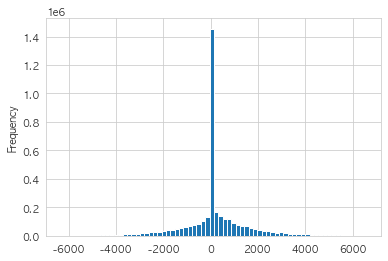

```python
# 전체 구간에 대한 히스토그램
plt.rcParams['axes.unicode_minus'] = False
pd.Series(sample).plot(kind='hist', bins=70)
plt.show()
```

- 해당 분포에는 "대차"와 "추가구매" 뿐만 아니라 "최초구매", "미분류"로 분류된 엔트리들에 대한 정보도 포함되어 있음.
- "대차"와 "추가구매"에 대해서만 관심이 있으므로, 히스토그램의 범위를 상식적인 수준인 6개월 이내로 좁혀 분포를 파악.

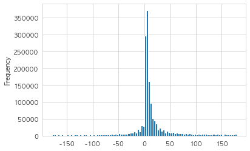

```python
# 6개월 이내의 히스토그램
pd.Series(sample)[list((pd.Series(sample) < 180) & (pd.Series(sample) > -180))].plot(kind="hist", bins=100)
plt.show()
```

cf) 분포의 모양 자체가 낮은 값들에 크게 편중되어 있기 때문에, 여러번의 시행 결과 범위를 3개월~8개월 선으로 조정하더라도 대차와 추가구매의 경향성은 크게 바뀌지 않는 것을 확인할 수 있었음.

결론적으로 대략 30일 정도 이내에 대부분의 값들이 분포되어 있는 것을 시각적으로 확인할 수 있음.

- 기술통계량 값을 바탕으로 좀 더 구체적인 수치를 파악하자.

```
count    1.602850e+06
mean     1.036618e+01
std      4.754134e+01
min     -1.790000e+02
25%      2.000000e+00
50%      6.000000e+00
75%      1.500000e+01
max      1.790000e+02
dtype: float64
```

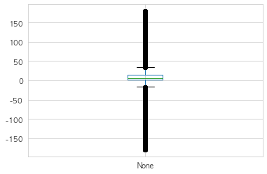

```python
print(pd.Series(sample)[list((pd.Series(sample) < 180) & (pd.Series(sample) > -180))].describe())
pd.Series(sample)[list((pd.Series(sample) < 180) & (pd.Series(sample) > -180))].plot(kind="box")
plt.show()
```

사분위수와 상자그림을 기준으로 할 때 **약 -18일 ~ 35일 사이에 대부분의 값들이 분포**된 것을 확인할 수 있음.

- **대차를 목적으로 차량을 처분하는 경우, 대부분의 고객들에서 대차 소요 기간이 대략 한달 내외라는 것을 의미**.
- **양수 값들이 음수값들 보다 많은 이유는 신차가 출고된 다음 기존 보유 차량을 처분하는 것이 일반적이기 때문**.

앞서 정의한 **"대차 상한값"**과 **"대차 하한값"**을 위 상자그림에서의 위스커(whisker) 값들을 바탕으로 설정.

- 위스커 바깥 범위에 속한 값들을 통계적 이상치라고 정의할 수 있음.

단, 히스토그램의 분포를 고려해 위스커 값에 어느 정도 오차를 고려해서 일주일을 더하고 뺀 값을 "대차 상한값"과 "대차 하한값"으로 설정.

```python
quartiles = pd.Series(sample)[list((pd.Series(sample) < 180) & (pd.Series(sample) > -180))].describe()

# 사분범위(Interquartile Range)를 바탕으로 이상치의 기준 정의하기
IQR = quartiles["75%"] - quartiles["25%"]
lower_whisker = quartiles["25%"] - (1.5 * IQR)
upper_whisker = quartiles["75%"] + (1.5 * IQR)

print(lower_whisker)
print(upper_whisker)
```

```
-17.5
34.5
```

```python
lower_boundary = np.round(lower_whisker) - 7
upper_boundary = np.round(upper_whisker) + 7

print("대차 하한값: {} 일".format(lower_boundary))
print("대차 상한값: {} 일".format(upper_boundary))
```

```
대차 하한값: -25.0 일
대차 상한값: 41.0 일
```

### 재구매유형 분류

앞서 정의한 "대차 상한값"과 "대차 하한값"을 바탕으로 재구매 유형 분류 알고리즘을 실행.

```python
# 해당 기간 동안 적어도 2번 이상 차량 구매를 고객들의 데이터
df_re = df_merged[df_merged.TOTAL_NUM_PURCHASES > 1]

# 해당 고객들의 ID
customer_id = pd.Series(df_re.CUS_ID.unique())
```

```python
# 알고리즘 실행 (완료까지 약 13시간 정도 소요됩니다)
result = labelling(batch_size=100, customer_id=customer_id,
                   boundary_upper=upper_boundary, boundary_lower=lower_boundary,
                   df_re=df_re, save_path="./data/재구매유형_라벨.json", save_count=1)

"""

##### 중간에 작업이 끊긴 경우 아래의 코드를 실행하세요. (작업을 이어서 재수행) #####
label_dict = json.load(open("./data/labels.json"))
df_temp = df_re.copy()
df_temp["TYPE_PURCHASES"] = df_temp.CAR_ID.map(label_dict["TYPE"])
contid_index = df_temp[df_temp.TYPE_PURCHASES.isna()].index         # 아직 라벨링이 진행안된 고객ID들의 인덱스
customer_id_contd = list(df_temp.CUS_ID[contid_index].unique())     # 아직 라벨링이 진행안된 고객ID 리스트

# 라벨링 재실행
result = labelling(batch_size=100, customer_id=customer_id_contd, boundary_upper=upper_boundary, boundary_lower=lower_boundary,
                   finished_dict=label_dict , df_re=df_re, save_path="./data/labels.json", save_count=1)

json.dump(result_contid, open("./data/labels.json", 'w'))
"""
```

- 알고리즘의 실행시간이 오래걸리므로, 앞서 샘플링과 마찬가지로 별도의 환경에서 진행함.
- 저장된 결과를 불러와 진행.

```python
# 완료된 데이터 불러오기
import json
label_dict = json.load(open("./data/재구매유형_라벨.json"))

# 각 차량ID에 대해 값들이 제대로 저장됐는지 확인
print(label_dict["TYPE"].keys() == label_dict["NUM_PURCHASES"].keys())
print(label_dict["NUM_PURCHASES"].keys() == label_dict["NUM_CONTID_CARS"].keys())
```

```
True
True
```

각 차량 ID마다 추가적인 정보가 제대로 수집된 것을 확인.

이를 바탕으로 기존의 데이터셋에 재구매 유형에 대한 정보를 추가.

```python
# 해당 기간 동안 적어도 2번 이상 차량 구매를 고객들의 데이터
df_re = df_merged[df_merged.TOTAL_NUM_PURCHASES > 1]

df = df_re.copy() # 최종적으로 사용할 데이터 (기존 재구매고객 데이터를 덮어쓰지 않기 위해 복사본 정의)

# 차량의 구매시점을 기준으로 여태까지 구매한 차량수 추가
df["UNTIL_TOTAL_NUM_PURCHASES"] = df.CAR_ID.map(label_dict["NUM_PURCHASES"])

# 차량의 구매시점을 기준으로 계속 보유중인 차량수 추가
df["UNTIL_NUM_CONTID_CARS"] = df.CAR_ID.map(label_dict["NUM_CONTID_CARS"])

# 구매유형 (최초구매 / 대차 / 추가구매) 라벨 추가
df["TYPE_PURCHASES"] = df.CAR_ID.map(label_dict["TYPE"])
```

```python
# 재구매 유형별 엔트리 수
df.TYPE_PURCHASES.value_counts()
```

```
최초구매    602223
추가구매    297652
대차      251529
미분류     181093
Name: TYPE_PURCHASES, dtype: int64
```

추가적으로, 고객의 접촉 이력에 대한 정보도 분석에 포함시키기 위해 특정한 차량의 **출고일을 기준으로 3개월 이내에 고객의 접촉 횟수**에 대한 데이터를 수집.

```python
# 전처리된 고객 접촉이력 데이터 불러오기
contacts = pd.read_csv("./data/접촉이력_전처리.csv")
contacts.CNTC_DT = pd.to_datetime(contacts.CNTC_DT)  # 날짜 자료형으로 변환
```

```python
start_time = time.time()

# 3개월 이내 접촉이력만 고려하기 위해 날짜 계산
contacts_contid = contacts[contacts.CUS_ID.isin(df.CUS_ID.unique())]
temp = pd.merge(contacts_contid[["CUS_ID", "CNTC_DT"]], df[["CUS_ID", "WHOT_DT"]], on="CUS_ID", how="left")
temp["DT_DIFF"] = temp["WHOT_DT"] - temp["CNTC_DT"]
temp["DT_DIFF"] = temp.DT_DIFF.apply(lambda x: x.days)

# 3개월 이내 접촉횟수 추가
num_contacts_dict = dict(temp[(temp.DT_DIFF <= 90) & (temp.DT_DIFF >= -7)].groupby("CUS_ID").count()["CNTC_DT"])
df["NUM_CONTACTS"] = df.CUS_ID.map(num_contacts_dict)
df["NUM_CONTACTS"] = df.NUM_CONTACTS.fillna(0)

# 라벨링 완료된 데이터셋 저장
df.to_csv("./data/차량구매내역_라벨링.csv", index=False)

print("--- %s seconds ---" % (time.time() - start_time))
```

```
--- 361.6131341457367 seconds ---
```

### 시각화

T-SNE 차원축소 알고리즘을 이용해 재구매유형 분류 결과를 시각화.

- 실행 속도를 위해 데이터셋에서 10만개의 엔트리를 샘플링해 알고리즘 진행.

```python
# 라벨링된 데이터 불러오기
df = pd.read_csv("./data/차량구매내역_라벨링.csv")

# 시각화를 위해 데이터셋에서 일부 샘플링
df_viz = df[(df.TYPE_PURCHASES == "대차") | (df.TYPE_PURCHASES == "추가구매")]
df_viz = df_viz[["CLB_HOUS_PYG_NM", "REAI_BZTC_AVG_PCE", "PCE_PER_PYG", "CAR_HLDG_DURATION", "TOTAL_NUM_PURCHASES",
             "CUS_AGE", "UNTIL_TOTAL_NUM_PURCHASES", "UNTIL_NUM_CONTID_CARS", "NUM_CONTACTS", "TYPE_PURCHASES"]]
df_viz = df_viz.dropna().sample(100000)

df_viz.TYPE_PURCHASES.value_counts()
```

```python
X = df_viz.drop("TYPE_PURCHASES", axis=1)
y = df_viz.TYPE_PURCHASES

# 시각화를 위해 수치형 특성 스케일링 진행
from sklearn.preprocessing import StandardScaler

std_scaler = StandardScaler()
X_scaled = pd.DataFrame(std_scaler.fit_transform(X), columns=X.columns)
```

```python
from MulticoreTSNE import MulticoreTSNE as TSNE

start_time = time.time()

tsne = TSNE(n_jobs=-1)
X_reduced = tsne.fit_transform(X_scaled)

print("--- %s seconds ---" % (time.time() - start_time))
```

```
--- 603.0703704357147 seconds ---
```

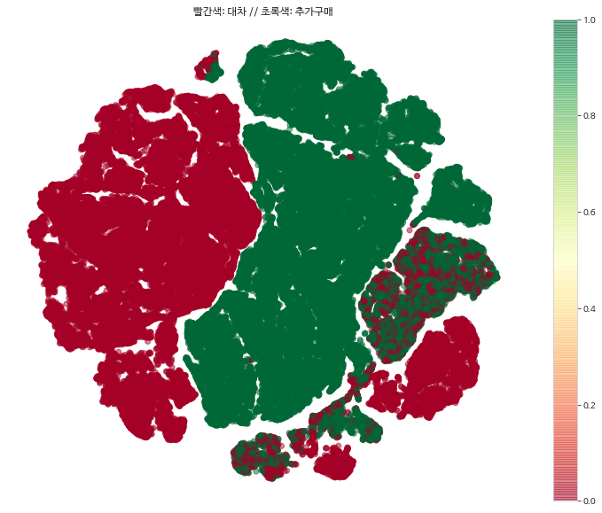

```python
# 각 그룹별 색상 매핑
label_encoder = {"대차": 0, "추가구매": 1}
y_encoded = y.map(label_encoder)

# 시각화
plt.figure(figsize=(13,10))
plt.scatter(X_reduced[:, 0], X_reduced[:, 1], c=y_encoded, cmap="RdYlGn", alpha=0.5)
plt.axis('off')
plt.title("빨간색: 대차 // 초록색: 추가구매")
plt.colorbar()
plt.show()
```

- 대차와 추가구매 집단이 일정한 경향성을 갖고 분리되어 있는 것을 시각적으로 확인할 수 있음.

## EDA

- 대차/추가구매 구분 결과에 대해 각각 EDA를 수행해 고객과 차량 관점에서 특징/차이점을 도출

```python
# 라벨링된 데이터셋 불러오기
df = pd.read_csv("./data/차량구매내역_라벨링.csv")

# 날짜 자료형 변환
df["WHOT_DT"] = pd.to_datetime(df["WHOT_DT"])
df["CAR_HLDG_FNH_DT"] = pd.to_datetime(df["CAR_HLDG_FNH_DT"])
print(df.shape)
```

```
(1332497, 28)
```

### 분석용 데이터셋 정의

주어진 데이터셋에서 **고객과 관련한 정보들은 시점의 영향을 받음**.

- ex) 고객의 거주 주택에 대한 정보가 10년 전에 구매한 차량에 대해서도 동일하다고 단정지을 수 없음.

또한 한 명의 고객이 여러 대의 차량 구매 내역을 가질 수 있기 때문에, 고객 관점에서 특징적인 인사이트를 도출하기 위해 별도로 분석용 데이터셋을 정의.

- 구체적으로, **고객별 현재 보유중인 차량들 중 출고일이 가장 최신인 엔트리들만 뽑아 고객 분석용 데이터셋을 정의.**

```python
# 분석용 데이터셋 정의

def get_most_recent_entry(df):
    """
    특정한 고객의 구매내역 데이터프레임을 받은 후, 그 중에서 출고일이 가장 최근인 엔트리를 반환하는 함수.
    판다스의 groupby 메소드를 사용하는데 필요한 보조함수.
    """
    # 현재 보유중인 차량에 대한 정보만 추출
    df = df[df.CAR_HLDG_IS_CONTID == "Y"]

    # 현재 보유중인 차량의 경우 가장 마지막 엔트리(출고일이 가장 최신)만 반환
    if len(df) >= 1:
        return df.iloc[-1,:]

    # 보유중인 차량이 없는 경우 아무것도 반환 x
    else:
        return None



def get_df_analysis(batch_size=10000, df=None):
    """
    시점에따라 가변적인 변수들을 분석하기 위한 데이터프레임을 정의.
        --> 주어진 데이터셋에서 차량을 최소 2번 이상 구매한 이력이 있는 재구매 고객들에 대해서,
            현재 보유하고 있는 차량들 중 가장 최신의 출고일을 갖는 엔트리들만 반환.

    판다스의 groupby 메소드를 이용하는 과정에서 메모리 절약을 위해 한번에 일정 크기의 데이터셋을 인덱싱해 작업 진행.

    <파라미터>
        batch_size: 한번에 실행할 배치 크기
        df: 정보를 추출할 재구매 차량들에 대한 데이터
    """
    import time
    start_time = time.time()

    cus_id = df.CUS_ID.unique()                  # 고객들의 고유한 id 리스트
    total_df = pd.DataFrame(columns=df.columns)  # 정보를 저장해둘 데이터프레임


    # 한번에 전체 데이터셋에서 일부의 데이터셋만을 추출해 차례대로 진행
    for i in tqdm(range(0, len(cus_id), batch_size)):
        batch_ids = cus_id[i:i+batch_size]
        batch_df = df[df.CUS_ID.isin(batch_ids)]
        batch_groupby = batch_df.groupby(["CUS_ID"]).apply(get_most_recent_entry).reset_index(drop=True)  # 특정한 고객의 보유 차량 중 가장 최신 출고차량의 정보

        # 기존 데이터프레임에 추가
        total_df = total_df.append(batch_groupby).reset_index(drop=True)
        print("--- %s seconds ---" % (time.time() - start_time))
        start_time = time.time()


    # 오류가 발생한 엔트리 제거
    total_df = total_df.dropna(subset=["CUS_ID"]).reset_index(drop=True)
    return total_df
```

```python
# 분석용 데이터셋 정의 (실행에 약 8분 정도 소요됩니다.)
df_repur = df[(df.TYPE_PURCHASES != "최초구매") & (df.TYPE_PURCHASES != "미분류")]  # 재구매 데이터셋
df_analysis = get_df_analysis(batch_size=10000, df=df_repur)

# 분석용 데이터 저장
df_analysis.to_csv("./data/차량구매내역_분석용.csv", index=False)
```

### 고객 관점에서의 분석

앞서 정의한 분석용 데이터를 바탕으로 진행.

```python
# 분석용 데이터 불러오기
df_analysis = pd.read_csv("./data/차량구매내역_분석용.csv")

# 날짜 자료형 변환
df_analysis["WHOT_DT"] = pd.to_datetime(df_analysis["WHOT_DT"])
df_analysis["CAR_HLDG_FNH_DT"] = pd.to_datetime(df_analysis["CAR_HLDG_FNH_DT"])

print(df_analysis.TYPE_PURCHASES.value_counts())
df_analysis.head(3)
```

```
대차      169411
추가구매    160656
Name: TYPE_PURCHASES, dtype: int64
```

|  | CUS_ID | PSN_BIZR_YN | SEX_SCN_NM | CUS_ADM_TRY_NM | CUS_N_ADMZ_NM | CUS_ADMB_NM | CLB_HOUS_PYG_NM | REAI_BZTC_AVG_PCE | B_YEAR | PCE_PER_PYG | ... | CAR_CLASS | CAR_ENG_CAT | CAR_TRIM_CAT | TOTAL_NUM_PURCHASES | CUS_AGE | CUS_AGE_CAT | TYPE_PURCHASES | UNTIL_TOTAL_NUM_PURCHASES | UNTIL_NUM_CONTID_CARS | NUM_CONTACTS |
| --- | --- | --- | --- | --- | --- | --- | --- | --- | --- | --- | --- | --- | --- | --- | --- | --- | --- | --- | --- | --- | --- |
| 0 | AONEEOO020000165 | Y | 남자 | 부산광역시 | 금정구 | NaN | NaN | NaN | 1951.0 | NaN | ... | 승용_고급 | 가솔린 | 중 | 2.0 | 59.0 | 50대 | 추가구매 | 1.0 | 1.0 | 4.0 |
| 1 | AONEEOO040000233 | Y | 남자 | 경기도 | 양주시 | 남면 | NaN | NaN | 1953.0 | NaN | ... | 승용_준중형 | 가솔린 | 상 | 2.0 | 56.0 | 50대 | 추가구매 | 1.0 | 1.0 | 2.0 |
| 2 | AONEEOO050000363 | N | 남자 | NaN | NaN | NaN | 45.0 | 85200.0 | 1960.0 | 1893.333333 | ... | 승용_중형 | 가솔린 | 중 | 4.0 | 57.0 | 50대 | 대차 | 3.0 | 1.0 | 38.0 |

3 rows × 28 columns

```python
# 분석용 데이터에서의 추가구매 데이터
anal_add = df_analysis[df_analysis.TYPE_PURCHASES == "추가구매"]
print(anal_add.shape)

# 분석용 데이터에서의 대차 데이터
anal_sub = df_analysis[(df_analysis.TYPE_PURCHASES == "대차")]
print(anal_sub.shape)
```

```
(160656, 28)
(169411, 28)
```

대차와 추가구매의 비율이 거의 엇비슷 하므로 바로 분석을 진행해도 무방.

#### 개인사업자 비율 차이

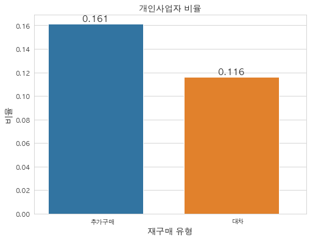

```python
# 개인사업자 비율
add_PSN_BIZR_YN_ratio = np.round(len(anal_add[anal_add.PSN_BIZR_YN == "Y"]) / len(anal_add), 4)
sub_PSN_BIZR_YN_ratio = np.round(len(anal_sub[anal_sub.PSN_BIZR_YN == "Y"]) / len(anal_sub), 4)

# 막대그래프 그리기
plt.figure(figsize=(8,6))
plots = sns.barplot(x=["추가구매", "대차"], y=[add_PSN_BIZR_YN_ratio, sub_PSN_BIZR_YN_ratio])
for bar in plots.patches:
    bar.set_width(0.7)
    plots.annotate(format(bar.get_height(), '.3f'),
                   (bar.get_x() + bar.get_width() / 2,
                    bar.get_height()), ha='center', va='center',
                   size=14, xytext=(0, 8),
                   textcoords='offset points')


plt.xlabel("재구매 유형",size=14)
plt.ylabel("비율",size=14)
plt.title("개인사업자 비율",size=14)
plt.show()
```

- 대차 고객들에 비해 추가구매 고객들에서 개인 사업자 비율이 더 높음.
- **개인 사업자 고객들은 구매력이 높으며 업무용 차량으로 인한 추가적인 수요가 있을 수 있기 때문에 타당한 결과라고 할 수 있음.**

단, 개인사업자 여부가 결측치인 고객들을 개인사업자가 아니라고 단정지을 수는 없으므로 일반화하기에는 한계가 있다.

#### 성별 비율 차이

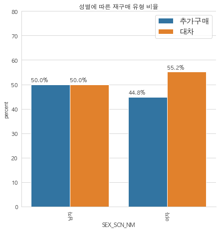

```python
x,y = 'SEX_SCN_NM', 'TYPE_PURCHASES'

df1 = df_analysis.groupby(x)[y].value_counts(normalize=True)
df1 = df1.mul(100)
df1 = df1.rename('percent').reset_index()

g = sns.catplot(x=x,y='percent', hue=y, kind='bar', data=df1, height=6, legend=False)
g.ax.set_ylim(0,80)

for p in g.ax.patches:
    txt = str(p.get_height().round(1)) + '%'
    txt_x = p.get_x()
    txt_y = p.get_height() + 1
    g.ax.text(txt_x,txt_y,txt)

plt.legend(loc='upper right', fontsize=15)
plt.title("성별에 따른 재구매 유형 비율")
plt.tick_params(axis='x', rotation=90)
plt.show()
```

대차와 추가구매 집단에서 남성의 비율은 거의 동일한 반면, 여성의 비율은 대차가 약 10.4%p 정도 높음.

- **여성 고객들의 경우 남성 고객들보다 실수요에 의한 차량 구입 성향이 큰 것으로 판단됨.**

#### 거주 지역

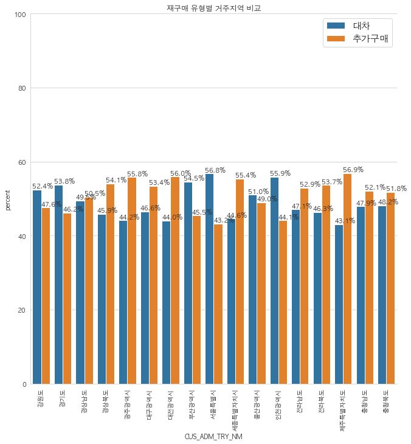

```python
x,y = 'CUS_ADM_TRY_NM', 'TYPE_PURCHASES'

df1 = df_analysis.groupby(x)[y].value_counts(normalize=True)
df1 = df1.mul(100)
df1 = df1.rename('percent').reset_index()


g = sns.catplot(x=x,y='percent', hue=y, kind='bar', data=df1, height=9, legend=False)
g.ax.set_ylim(0,100)


for p in g.ax.patches:
    txt = str(p.get_height().round(1)) + '%'
    txt_x = p.get_x()
    txt_y = p.get_height() + 0.3
    g.ax.text(txt_x,txt_y,txt)

plt.legend(loc='upper right', fontsize=15)
plt.title("재구매 유형별 거주지역 비교")
plt.tick_params(axis='x', rotation=90)
plt.show()
```

**대차의 비율이 더 높은 지역**

- 강원도, 경기도, 부산광역시, 서울특별시, 인천광역시 (서울 포함 수도권 및 부산)

**추가구매의 비율이 더 높은 지역**

- 경상도, 광주광역시, 대구광역시, 대전광역시, 세종시, 전라도, 제주도, 충청도 (지방)

교통인프라 수준과 추가구매 수요간에 음의 상관관계가 있다고 판단됨.

- **지방 도시들은 상대적으로 교통 인프라가 덜 발전되었기 때문에 교통수단으로써의 추가구매의 비율이 높음.**
- **이와는 반대로 수도권 및 부산과 같은 대도시의 경우 발전된 대중교통 시설로 인해 추가구매의 니즈가 지방에 비해 상대적으로 낮음.**

#### 나이

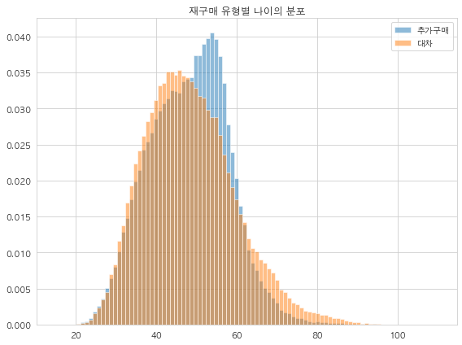

```python
plt.figure(figsize=(8,6))

# 현재 시점에서의 나이
bins = np.linspace(15, 110, 95)
add_CUS_AGE = anal_add.CUS_AGE.dropna()
sub_CUS_AGE = anal_sub.CUS_AGE.dropna()

plt.hist(add_CUS_AGE, bins, alpha=0.5, label='추가구매', density=True)
plt.hist(sub_CUS_AGE, bins, alpha=0.5, label='대차', density=True)
plt.legend(loc='upper right')
plt.title("재구매 유형별 나이의 분포")

plt.tight_layout()
plt.show()
```

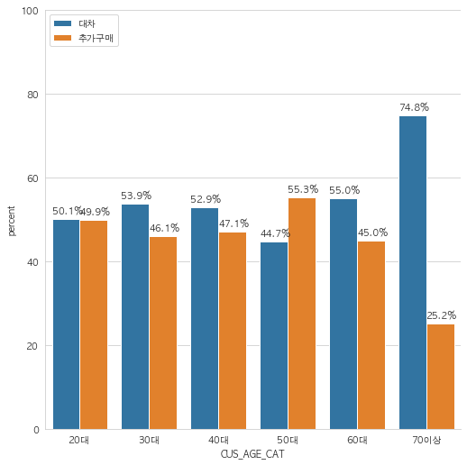

```python
x,y = 'CUS_AGE_CAT', 'TYPE_PURCHASES'

df1 = df_analysis.groupby(x)[y].value_counts(normalize=True)
df1 = df1.mul(100)
df1 = df1.rename('percent').reset_index()

g = sns.catplot(x=x,y='percent', hue=y, kind='bar', data=df1, height=7, legend=False)
g.ax.set_ylim(0,100)

for p in g.ax.patches:
    txt = str(p.get_height().round(1)) + '%'
    txt_x = p.get_x()
    txt_y = p.get_height() + 1
    g.ax.text(txt_x,txt_y,txt)

plt.legend(loc='upper left')
plt.show()
```

- **50대에서만 추가구매의 비율이 더 높음.**
- 결론적으로, 어느 정도 경제력이 있으며 자식과 배우자가 있는 50대의 고객들에서 추가구매의 수요가 높다고 해석됨.
- 한편, 70대 이상부터는 대차의 비율이 급격하게 높아짐.
  - 경제 활동 여부와 추가구매에 대한 수요간 상관관계가 있는 것으로 보임

### 차량 관점에서의 분석

차량과 관련한 변수들은 특정 시점에 의존받지 않으므로 전체 데이터셋을 사용해 분석을 진행.

```python
# 전체 데이터셋 중 대차와 추가구매 엔트리
df_full = df[(df.TYPE_PURCHASES == "대차") | (df.TYPE_PURCHASES == "추가구매")]

full_add = df_full[df_full.TYPE_PURCHASES == "추가구매"]     # 전체 대차 데이터
full_sub = df_full[df_full.TYPE_PURCHASES == "대차"]         # 전체 추가구매 데이터
```

#### 차량 출고일

연월별 출고된 차량수는 판매량으로 해석할 수 있음.

```python
df_full.loc[:, "WHOT_DT_YM"] = df_full.WHOT_DT.dt.strftime("%Y%m")   # 출고일의 연/월 정보를 따로 떼어내 새로운 칼럼 지정
df_full.loc[:, "WHOT_DT_Y"] = df_full.WHOT_DT.dt.strftime("%Y")      # 출고일의 연도 정보를 따로 떼어내 새로운 칼럼 지정
df_full.loc[:, "WHOT_DT_M"] = df_full.WHOT_DT.dt.strftime("%m")      # 출고일의 연도 정보를 따로 떼어내 새로운 칼럼 지정

# 출고일을 기준으로 출고차량수 집계
timeseries_WHOT_DT = df_full.pivot_table(index="WHOT_DT_YM", columns="TYPE_PURCHASES", aggfunc="size", fill_value=0)       # 전체
timeseries_WHOT_DT_year = df_full.pivot_table(index="WHOT_DT_Y", columns="TYPE_PURCHASES", aggfunc="size", fill_value=0)   # 연도별
timeseries_WHOT_DT_month = df_full.pivot_table(index="WHOT_DT_M", columns="TYPE_PURCHASES", aggfunc="size", fill_value=0)  # 월별
```

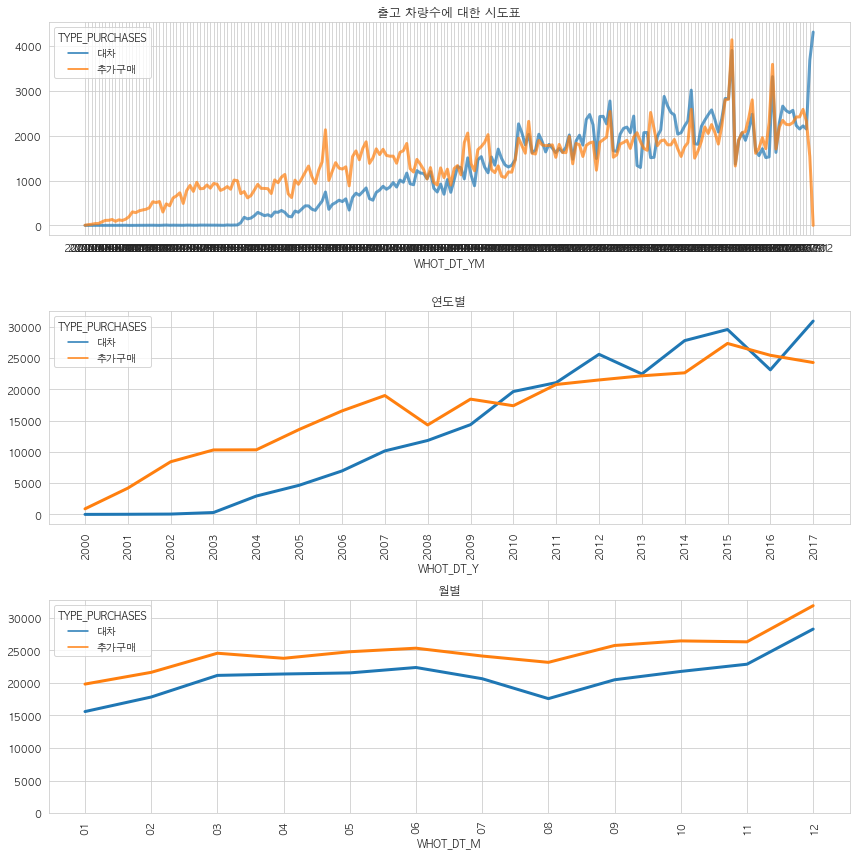

```python
# 시각화
fig, axs = plt.subplots(3, 1, figsize=(12,12))

# 전체 시도표
sns.lineplot(ax = axs[0], data = timeseries_WHOT_DT, palette = "tab10", dashes=False, linewidth = 3, alpha=0.7)
axs[0].set_title("출고 차량수에 대한 시도표")

# 연도별 시도표
sns.lineplot(ax = axs[1], data = timeseries_WHOT_DT_year, palette = "tab10", dashes=False, linewidth = 3)
axs[1].set_title("연도별")
axs[1].tick_params(axis='x', rotation=90)

# 월별 시도표
sns.lineplot(ax = axs[2], data = timeseries_WHOT_DT_month, palette = "tab10", dashes=False, linewidth = 3)
axs[2].set_title("월별")
plt.ylim(bottom=0)
axs[2].tick_params(axis='x', rotation=90)

plt.tight_layout()
plt.show()
```

#### 차량 보유 기간

보유종료된 차량들에 대해서만 분석

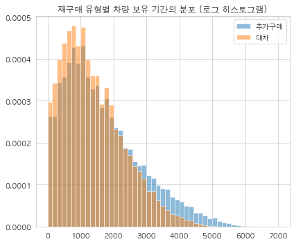

```python
plt.figure(figsize=(6,5))

# 차량 보유 기간
bins = np.linspace(0, 7000, 50)
add_CAR_HLDG_DURATION = full_add[full_add.CAR_HLDG_IS_CONTID == "N"].CAR_HLDG_DURATION.dropna()
sub_CAR_HLDG_DURATION = full_sub[full_sub.CAR_HLDG_IS_CONTID == "N"].CAR_HLDG_DURATION.dropna()

plt.hist(add_CAR_HLDG_DURATION, bins, alpha=0.5, label='추가구매', density=True)
plt.hist(sub_CAR_HLDG_DURATION, bins, alpha=0.5, label='대차', density=True)
plt.legend(loc='upper right')
plt.title("재구매 유형별 차량 보유 기간의 분포 (로그 히스토그램)")

plt.tight_layout()
plt.show()
```

추가구매 집단이 대차 집단에 비해 차량의 보유기간이 긴 것을 확인할 수 있음.

- **추가구매 차량들은 주행거리가 비교적 낮을 확률이 높기 때문에 연식에 비해 차량을 오랫동안 보유할 가능성이 있음.**
- **대차 차량은 다음 차량으로 또다시 대차할 가능성이 높기 때문에 추가구매에 비해 평균적으로 보유기간이 짧은 것이 타당함.**

#### 차량 등급

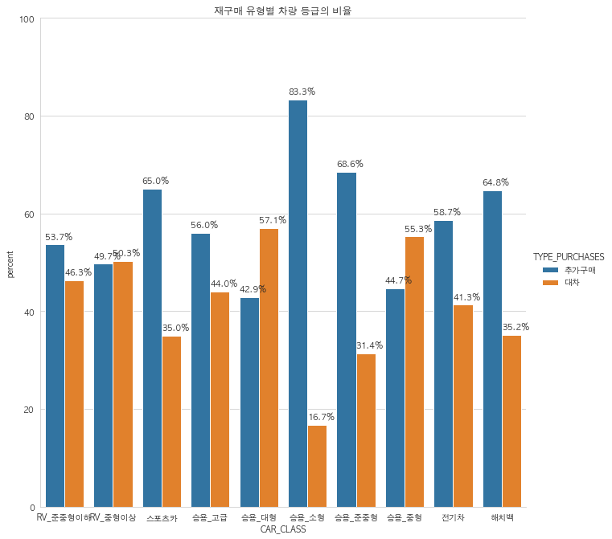

```python
x,y = 'CAR_CLASS', 'TYPE_PURCHASES'

df1 = df_full.groupby(x)[y].value_counts(normalize=True)
df1 = df1.mul(100)
df1 = df1.rename('percent').reset_index()


g = sns.catplot(x=x,y='percent', hue=y, kind='bar', data=df1, height=9)
g.ax.set_ylim(0,100)


for p in g.ax.patches:
    txt = str(p.get_height().round(1)) + '%'
    txt_x = p.get_x()
    txt_y = p.get_height() + 1
    g.ax.text(txt_x,txt_y,txt)

plt.title("재구매 유형별 차량 등급의 비율")
plt.show()
```

- 가격대가 있는 그렌저 등의 세단 모델을 여러대 보유하기는 쉽지 않기 때문.

**소형 승용차 그룹에서 추가구매의 비율이 압도적으로 높음.**

- 추가구매는 실제 니즈를 기반으로한 합리적인 소비일 가능성이 높으므로 비교적 부담없이 탈 수 있는 저렴한 차량들이 선호된다고 해석할 수 있음.
- 또한, 추가구매 차량의 경우 실소유주가 본인이 아닐 수 있음.
  - ex) 자신의 명의로 구매는 했지만, 자식 혹은 배우자가 차량을 모는 경우

#### 엔진분류

- 2007년 이전 데이터는 분석에서 제외.

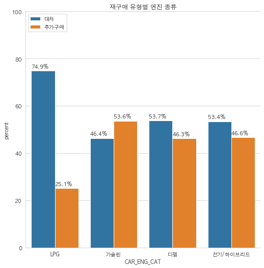

```python
x,y = 'CAR_ENG_CAT', 'TYPE_PURCHASES'

temp = df_full[df_full.CAR_ENG_CAT != "알수없음"]

df1 = temp.groupby(x)[y].value_counts(normalize=True)
df1 = df1.mul(100)
df1 = df1.rename('percent').reset_index()


g = sns.catplot(x=x,y='percent', hue=y, kind='bar', data=df1, height=7, legend=False)
g.ax.set_ylim(0,100)


for p in g.ax.patches:
    txt = str(p.get_height().round(1)) + '%'
    txt_x = p.get_x()
    txt_y = p.get_height() + 1
    g.ax.text(txt_x,txt_y,txt)

plt.title("재구매 유형별 엔진 종류")
plt.legend(loc='upper left')
plt.show()
```

**LPG 그룹에서 대차의 비율이 눈에 띄게 높음.**

- LPG 차량 (택시, 장애인, 렌트카, SUV, 트럭 등) 의 특성을 고려했을 때 효율성을 중시하는 고객의 성향이 반영된 결과라고 해석됨.
  - 특히나 해당 데이터의 시점인 2017년을 기준으로 할 때 일반인이 LPG 차량을 구매하기 위해서는 조건이 매우 까다로웠기 때문에 특수한 목적의 차량들일 가능성이 높음.

#### 트림 등급

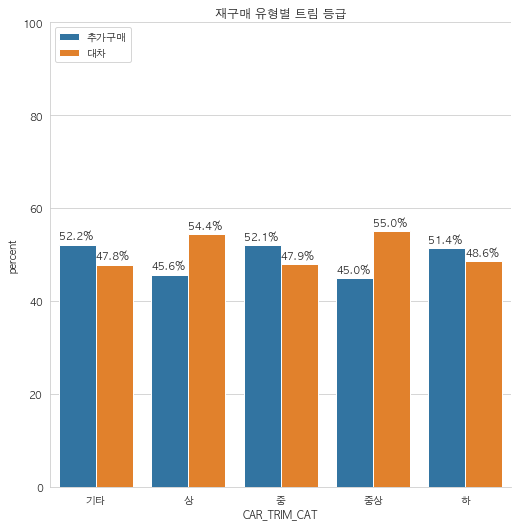

```python
x,y = 'CAR_TRIM_CAT', 'TYPE_PURCHASES'

temp = df_full[df_full.CAR_TRIM_CAT != "2007이전 데이터"]

df1 = temp.groupby(x)[y].value_counts(normalize=True)
df1 = df1.mul(100)
df1 = df1.rename('percent').reset_index()


g = sns.catplot(x=x,y='percent', hue=y, kind='bar', data=df1, height=7, legend=False)
g.ax.set_ylim(0,100)


for p in g.ax.patches:
    txt = str(p.get_height().round(1)) + '%'
    txt_x = p.get_x()
    txt_y = p.get_height() + 1
    g.ax.text(txt_x,txt_y,txt)

plt.title("재구매 유형별 트림 등급")
plt.legend(loc='upper left')
plt.show()
```

**대차 그룹에서는 중상급 이상 트림의 비율이 높은 반면, 추가구매 그룹에서는 중급 이하의 트림 비율이 높음.**

- 대차는 실수요에 따른 차량 구매일 확률이 높으므로 높은 등급의 옵션을 선호하는 경향이 있는 것이 합리적임.
  - 다시 말해, 해당 차량들은 구매자가 1순위로 타고 다니는 차량일 가능성이 높음 .
- 반면, 추가구매의 경우 단순한 운송 수단의 목적으로만 타고다닐 가능성이 높기 때문에 옵션에 크게 투자를 안하는 것이 타당함.

### 다변량 분석

고객 및 차량과 관련한 주요 변수들을 종합적으로 고려해서 추가적으로 분석을 진행.

#### 개인사업자 여부 & 차량 등급

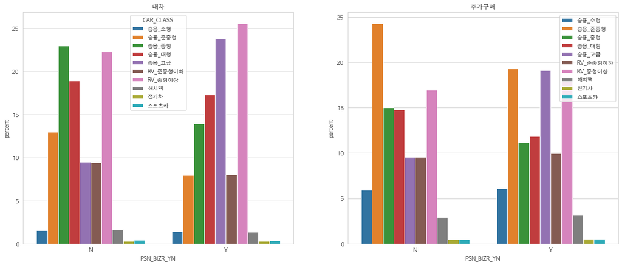

```python
# 성별 & 차량 등급별 비율 비교
fig, axs = plt.subplots(1, 2, figsize=(20, 8))
x,y = 'PSN_BIZR_YN', 'CAR_CLASS'

# 대차 그룹
temp1 = full_sub[full_sub.CAR_TRIM_CAT != "2007이전 데이터"]
df1 = temp1.groupby(x)[y].value_counts(normalize=True)
df1 = df1.mul(100)
df1 = df1.rename('percent').reset_index()

sns.barplot(ax = axs[0], x=x, y='percent', hue=y, data=df1,
            hue_order=["승용_소형", "승용_준중형", "승용_중형", "승용_대형", "승용_고급", "RV_준중형이하", "RV_중형이상", "해치백", "전기차", "스포츠카"])
axs[0].set_title("대차")


# 추가구매 그룹
temp2 = full_add[full_add.CAR_TRIM_CAT != "2007이전 데이터"]
df2 = temp2.groupby(x)[y].value_counts(normalize=True)
df2 = df2.mul(100)
df2 = df2.rename('percent').reset_index()

sns.barplot(ax = axs[1], x=x, y='percent', hue=y, data=df2,
            hue_order=["승용_소형", "승용_준중형", "승용_중형", "승용_대형", "승용_고급", "RV_준중형이하", "RV_중형이상", "해치백", "전기차", "스포츠카"])
axs[1].set_title("추가구매")


# 그래프 출력
plt.legend(loc='upper right')
plt.show()
```

대차와 추가구매 집단 모두 **개인사업자 등록 여부에 따라 고급 승용차(보라색 막대그래프)의 비율이 크게 차이가 나는 것을 확인할 수 있음.**

- 개인사업자 고객들의 선호도
  - 개인 사업자 고객들에게 자동차는 단순히 이동 수단을 넘어서, 본인의 경제적 능력과 사회적 지위를 과시하는 용도로 사용될 수 있음.
  - 비교적 가격대가 높은 모델을 선호하는 것은 이러한 성향이 반영된 결과로 해석됨.

#### 개인사업자 여부 & 접촉 횟수

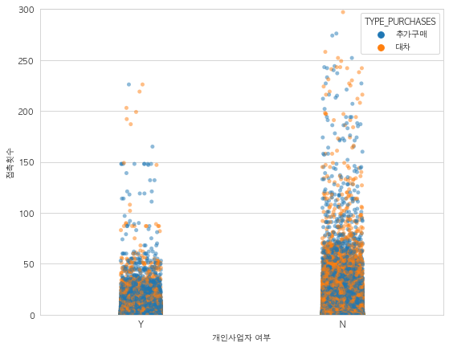

```python
plt.figure(figsize=(9,7))

ax = sns.stripplot(x="PSN_BIZR_YN", y="NUM_CONTACTS", data=df_full, hue="TYPE_PURCHASES", alpha=0.5)
ax.set(xlabel="개인사업자 여부")
ax.set(ylabel="접촉횟수")
plt.ylim(0,300)


plt.show()
```

개인사업자 고객들의 접촉횟수가 상대적으로 적은 것을 확인할 수 있음.

- 개인사업자 고객들은 지속구매대상이기 때문에 기본적으로 할인율이 높고, 딜러가 직접 찾아와 계약을 진행하는 경우가 많다고 함.
- 반면, 일반 고객들은 여러번 컨택을 하며 비교분석을 한 뒤 구매하는 것이 일반적.

#### 성별 & 차량등급

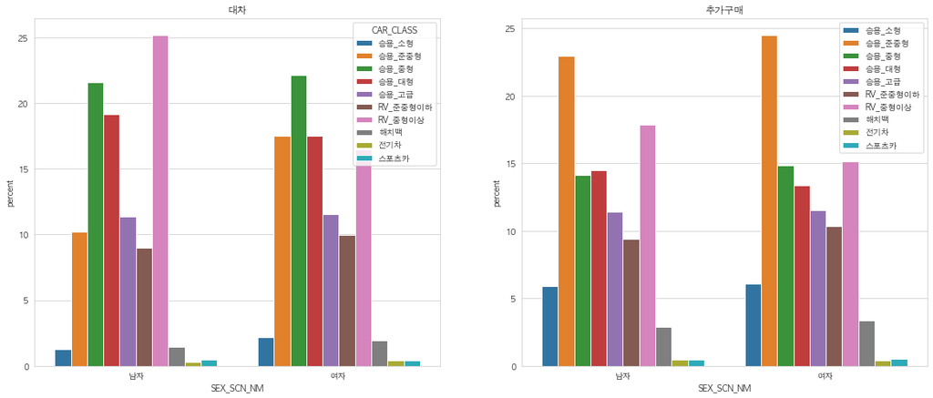

```python
# 성별 & 차량 등급별 비율 비교
fig, axs = plt.subplots(1, 2, figsize=(20, 8))
x,y = 'SEX_SCN_NM', 'CAR_CLASS'

# 대차 그룹
temp1 = full_sub[full_sub.CAR_TRIM_CAT != "2007이전 데이터"]
df1 = temp1.groupby(x)[y].value_counts(normalize=True)
df1 = df1.mul(100)
df1 = df1.rename('percent').reset_index()

sns.barplot(ax = axs[0], x=x, y='percent', hue=y, data=df1,
            hue_order=["승용_소형", "승용_준중형", "승용_중형", "승용_대형", "승용_고급", "RV_준중형이하", "RV_중형이상", "해치백", "전기차", "스포츠카"])
axs[0].set_title("대차")


# 추가구매 그룹
temp2 = full_add[full_add.CAR_TRIM_CAT != "2007이전 데이터"]
df2 = temp2.groupby(x)[y].value_counts(normalize=True)
df2 = df2.mul(100)
df2 = df2.rename('percent').reset_index()

sns.barplot(ax = axs[1], x=x, y='percent', hue=y, data=df2,
            hue_order=["승용_소형", "승용_준중형", "승용_중형", "승용_대형", "승용_고급", "RV_준중형이하", "RV_중형이상", "해치백", "전기차", "스포츠카"])
axs[1].set_title("추가구매")


# 그래프 출력
plt.legend(loc='upper right')
plt.show()
```

<성별에 따른 차량 등급별 순위>

**추가구매**

- 순위에 큰 차이 없음

**대차**

|  | 남성 | 여성 |
| --- | --- | --- |
| 1 | **RV_중형이상** | 승용_중형 |
| 2 | 승용_중형 | 승용_대형 |
| 3 | 승용_대형 | 승용_준중형 |
| 4 | 승용_고급 | **RV_중형이상** |
| 5 | 승용_준중형 | 승용_고급 |
| 6 | RV_준중형이하 | RV_준중형이하 |
| 7 | 해치백 | 해치백 |
| 8 | 승용_소형 | 승용_소형 |
| 9 | 스포츠카 | 스포츠카 |
| 10 | 전기차 | 전기차 |

- 여성 그룹에서 RV_중형이상의 비율에 큰 차이가 남.

여성들은 중형 이상급 RV를 선호하지 않는다고 해석할 수 있음.

- 단, 펠리셰이드 시리즈의 등장 및 최근 옵션에서의 편의성 강화로 인해 점차 트렌드가 변하고 있기 때문에 현시점에서 유의미한 결과는 아님.

#### 성별 & 접촉횟수

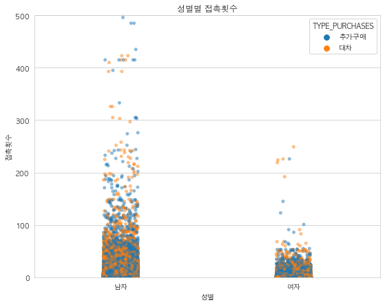

```python
plt.figure(figsize=(9,7))

ax = sns.stripplot(x="SEX_SCN_NM", y="NUM_CONTACTS", data=df_full, hue="TYPE_PURCHASES", alpha=0.5)
ax.set(xlabel="성별")
ax.set(ylabel="접촉횟수")
plt.ylim(0, 500)

plt.title("성별별 접촉횟수")
plt.show()
```

재구매 유형에 관계없이 남성 고객들의 접촉 횟수가 더 높음.

- 차량에 대한 관심도 차이라고 해석됨.

#### 나이 & 접촉횟수

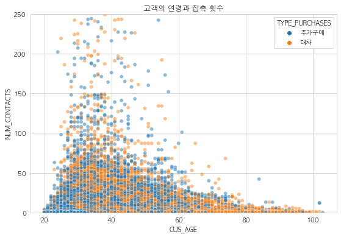

```python
plt.figure(figsize=(9,6))

sns.scatterplot(x="CUS_AGE", y="NUM_CONTACTS", hue="TYPE_PURCHASES", data=df_full, alpha=0.5)
plt.ylim(0, 250)

plt.title("고객의 연령과 접촉 횟수")

plt.show()
```

두 재구매 유형 모두에서 나이가 많을 수록 컨택수가 줄어드는 것을 확인할 수 있음.

#### 연령대별 인기 차량 모델

```python
def get_gender_num_pur(car_name):
    """
    특정한 차량 모델을 기준으로 성별, 연령대 별 구매 비율을 시각화 하는 함수
    """
    # 특정 모델에 대한 구매정보
    temp_df = df_full[df_full.CAR_NM == car_name]
    temp_female = temp_df[temp_df.SEX_SCN_NM == "여자"]
    temp_male = temp_df[temp_df.SEX_SCN_NM == "남자"]

    # 성별 & 차량 등급별 비율 비교
    fig, axs = plt.subplots(1, 2, figsize=(20, 8))
    x,y = 'TYPE_PURCHASES', 'CUS_AGE_CAT'

    # 여성 그룹
    temp1 = temp_female[temp_female.CAR_TRIM_CAT != "2007이전 데이터"]
    df1 = temp1.groupby(x)[y].value_counts(normalize=True)
    df1 = df1.mul(100)
    df1 = df1.rename('percent').reset_index()

    sns.barplot(ax = axs[0], x=x, y='percent', hue=y, data=df1,
                hue_order=["20대", "30대", "40대", "50대", "60대", "70이상"])
    axs[0].set_title(car_name + " - 여자")


    # 남성 그룹
    temp2 = temp_male[temp_male.CAR_TRIM_CAT != "2007이전 데이터"]
    df2 = temp2.groupby(x)[y].value_counts(normalize=True)
    df2 = df2.mul(100)
    df2 = df2.rename('percent').reset_index()

    sns.barplot(ax = axs[1], x=x, y='percent', hue=y, data=df2,
                hue_order=["20대", "30대", "40대", "50대", "60대", "70이상"])
    axs[1].set_title(car_name + " - 남자")


    # 그래프 출력
    plt.legend(loc='upper right')
    plt.show()
```

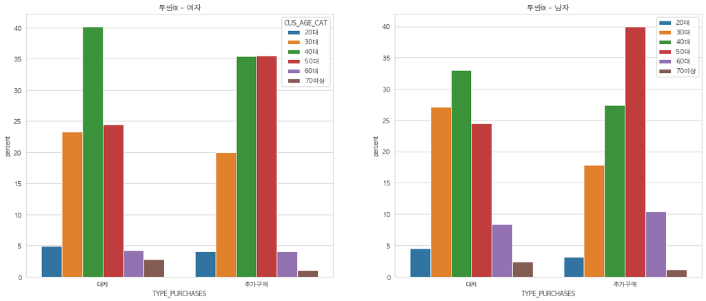

```python
# 다양한 차량 이름을 인자로 대입해 성별별, 연령대별 선호도를 시각화할 수 있음.
get_gender_num_pur("투싼ix")
```